# Day - 9, 10 & 11 - Exploratory Data Analytics

### Legends

Earlier we have seen that we can use colour as the third dimention in scatter plots. To know which points belongs to which category

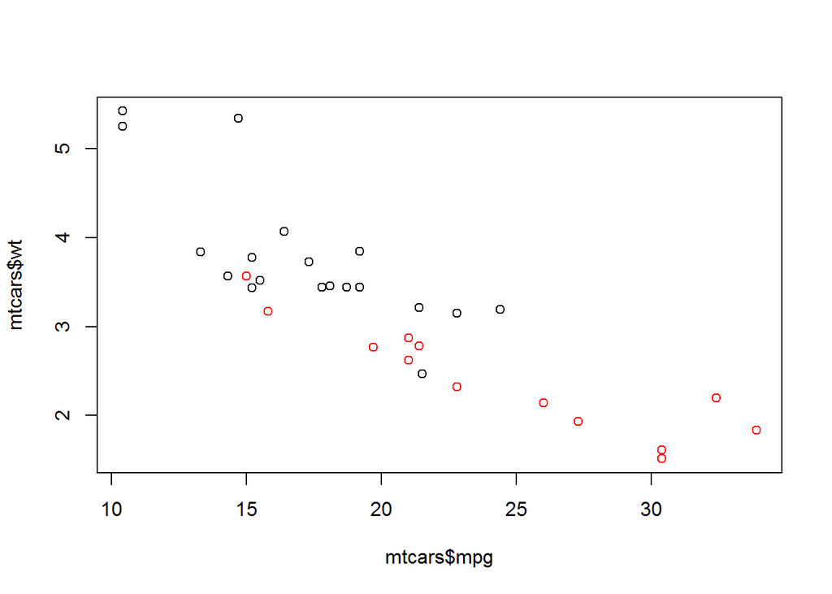

```r
> plot(mtcars$mpg, mtcars$wt, col = ifelse(mtcars$am == 1, "red", "black"))
```

Here in this plot if `am` is 1(manual) the point will be red in color and black otherwise. We can add a legend to the plot to mention this. To do that we use `legend()` function. The first argument specifies the position of legend, it can either be `topleft` or `topright` or `bottomleft` or `bottomright`. Then the `legend` parameter takes a vector of strings specifing the catogorical variable, such as automatic and malual. Then the `col` argument assignes color to respective values in `legend` parameter, like here automatic takes black color and manual takes red color. Finally, the `pch` argument specifies how the color markers are represented in legend. Using `pch` gives various shapes resembling points. You can also use `lty` parameter to specify them as lines.

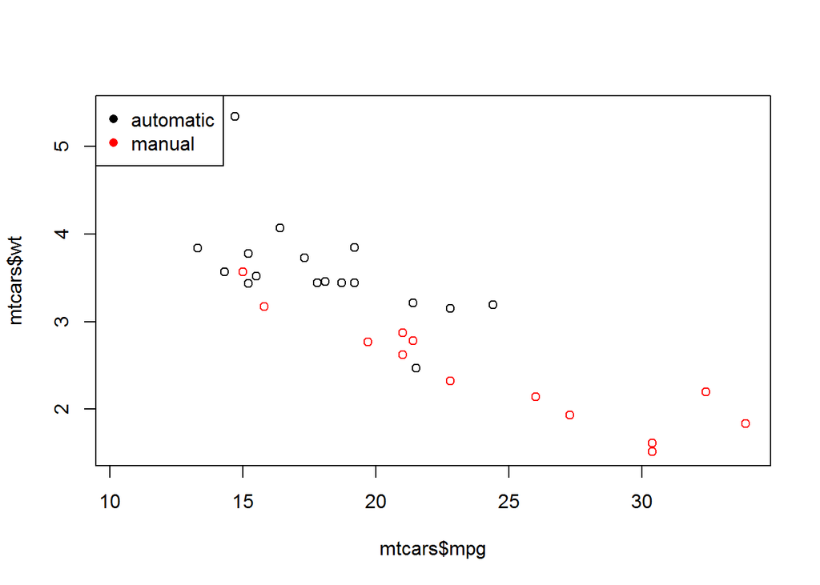

```r
> plot(mtcars$mpg, mtcars$wt, col = ifelse(mtcars$am == 1, "red", "black"))
>
> legend("topleft", legend = c("automatic", "manual"), col = c("black", "red"), pch = 16)
```

Using `lty` in legend.

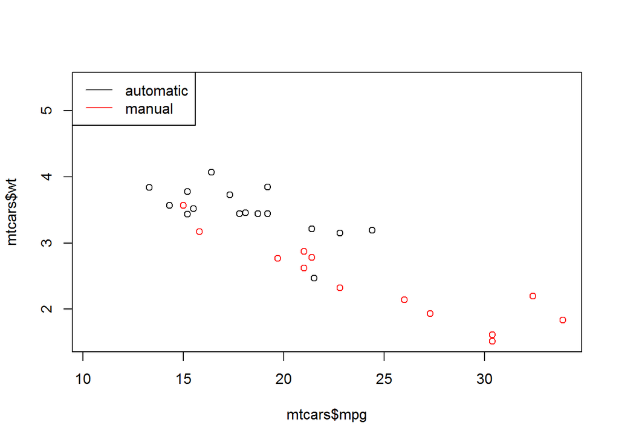

```r
> plot(mtcars$mpg, mtcars$wt, col = ifelse(mtcars$am == 1, "red", "black"))
>
> legend("topleft", legend = c("automatic", "manual"), col = c("black", "red"), lty = "solid")
```

One last thing about legends, for the first parameter we used `topleft`. Insterd of that we can give the coordinates to specify where we want the legend. But usually using `topleft`, `topright`, `bottomleft`, `bottomright` is prefarable.

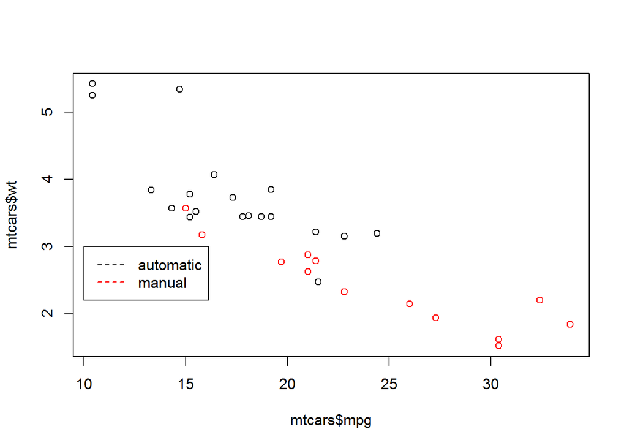

```r
> plot(mtcars$mpg, mtcars$wt, col = ifelse(mtcars$am == 1, "red", "black"))
>
> legend(10, 3, legend = c("automatic", "manual"), col = c("black", "red"), lty = "dashed")
```

**Quick Questions**

1. Using the `iris` data set plot a scatter plot between the variables `Sepal.Length` and `Petal.Length`, and in addition add color to the points based on `Species` variable. Try out several options and come up with the plot like the image as shown below.

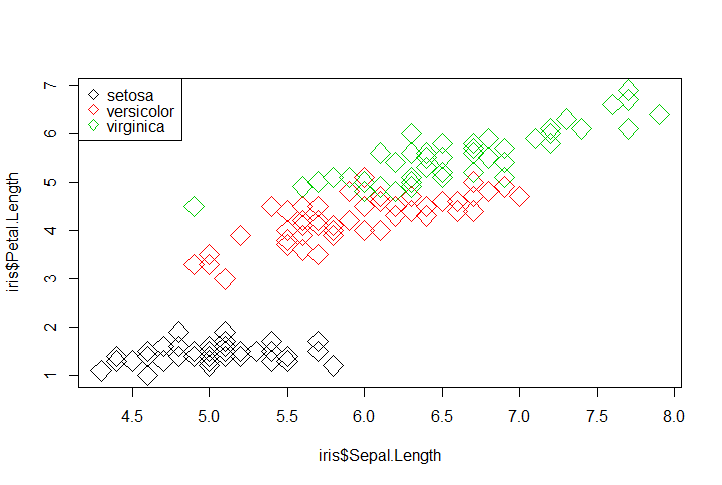

### with function

While using plot function, suppose for scatter plots to write the commands such as `plot(mtcars$mpg, mtcars$wt)`. This looks messy. To simply this we can use `with()` function. First argument is the data we want to use, and then you can give the plotting function without having to use `$` to refer columns.

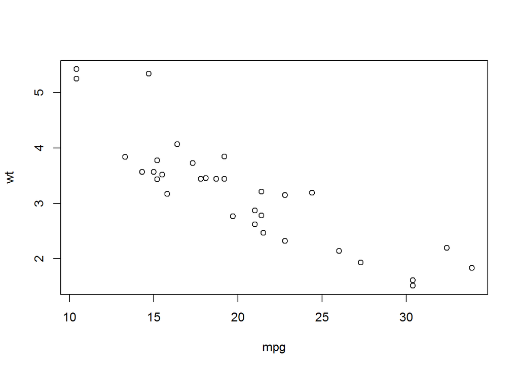

```r
> with(mtcars, plot(mpg, wt))
```

You can also draw multiple plots in a single line with `with()` function. Hear is a plot using `airquality` data.

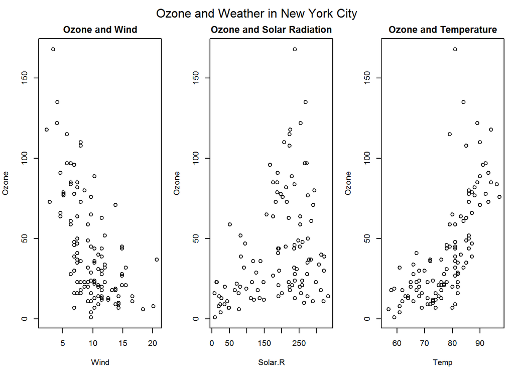

```r
> par(mfrow = c(1, 3), mar = c(4, 4, 2, 1), oma = c(0, 0, 2, 0))
> with(airquality,
+       { plot(Wind, Ozone, main = "Ozone and Wind")
+         plot(Solar.R, Ozone, main = "Ozone and Solar Radiation")
+         plot(Temp, Ozone, main = "Ozone and Temperature")
+         mtext("Ozone and Weather in New York City", outer = TRUE)
+       }
+     )
```

You can also use `with()` for any other functions also.

```r
> with(mtcars, max(wt))
## [1] 5.424
>
> with(mtcars, which.max(wt))
## [1] 16
```